# Project1

# Decision Tree with Imbalanced dataset.

```r
library(rpart)
cfit <- rpart(readmitted ~ time_in_hospital + num_lab_procedures + num_procedures + num_medications + number_outpatient + number_emergency + number_inpatient + race + age + admission_type_id + discharge_disposition_id + admission_source_id + number_diagnoses + max_glu_serum + A1Cresult + metformin + insulin, data = objTrain, method="class", minsplit = 20, minbucket = 5, cp = 0.001)
# minsplit = the minimum number of observations that must exist in a node in order for a split to be attempted.
# minbucket=the minimum number of observations in any terminal <leaf> node. If only one of minbucket or minsplit is specified, the code either sets minsplit to minbucket*3 or minbucket to minsplit/3, as appropriate.
# http://stackoverflow.com/questions/29620619/understanding-of-minbucket-function-in-cart-model-using-r

head(predict(cfit))
```

```
##           <30       >30        NO
## 6  0.08949183 0.3200420 0.5904662
## 7  0.08949183 0.3200420 0.5904662
## 9  0.08949183 0.3200420 0.5904662
## 12 0.08949183 0.3200420 0.5904662
## 14 0.08949183 0.3200420 0.5904662
## 25 0.07097383 0.2473473 0.6816788
```

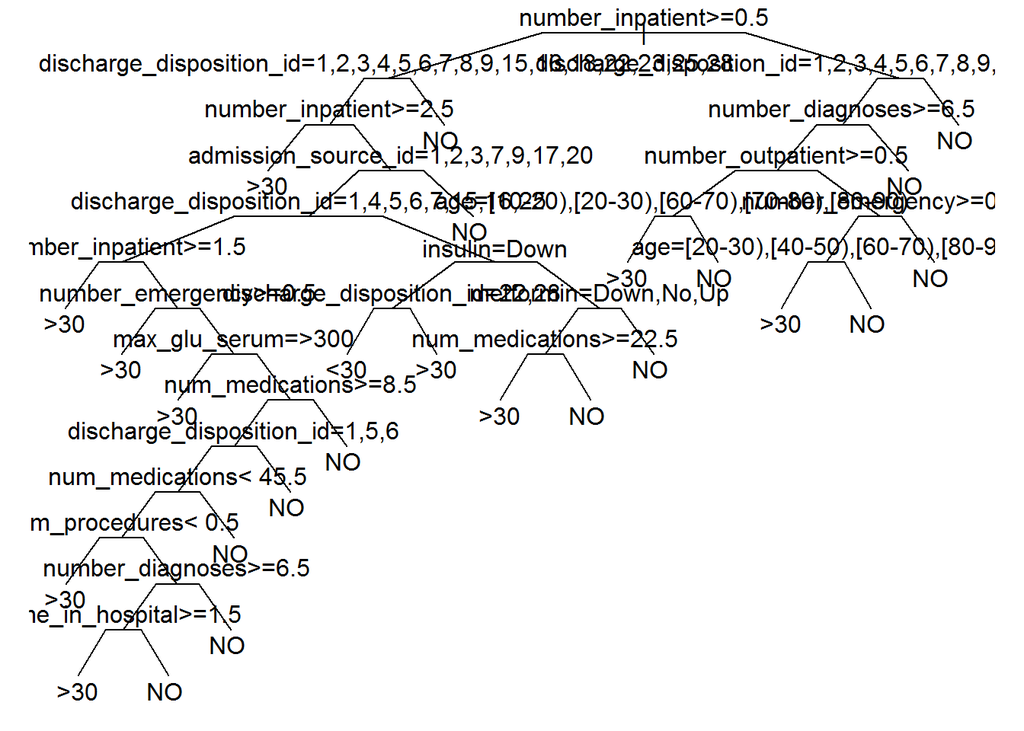

```r
par(mar=c(1,1,0.25,1))
plot(cfit, branch = 0.4,uniform = TRUE, compress = TRUE)
text(cfit, pretty = 0)
```

```r
rpart.predict <- predict(cfit, newdata = objTrain, type="class")
tail(rpart.predict)
```

```
## 101729 101740 101746 101756 101764 101765
##    >30    >30     NO    >30    >30     NO
## Levels: <30 >30 NO
```

```r
cf <-confusionMatrix(rpart.predict, objTrain$readmitted)
cf
```

```
## Confusion Matrix and Statistics
##
##           Reference
## Prediction  <30  >30   NO
##        <30   11    1    5
##        >30 1000 2882 1930
##        NO  1203 4013 8567
##
## Overall Statistics
##
##                Accuracy : 0.5843
##                  95% CI : (0.5774, 0.5912)
##     No Information Rate : 0.5355
##     P-Value [Acc > NIR] : < 2.2e-16
##
##                   Kappa : 0.1997
##  Mcnemar's Test P-Value : < 2.2e-16
##
## Statistics by Class:
##
##                      Class: <30 Class: >30 Class: NO
## Sensitivity           0.0049684     0.4179    0.8157
## Specificity           0.9996551     0.7696    0.4274
## Pos Pred Value        0.6470588     0.4959    0.6216
## Neg Pred Value        0.8875734     0.7091    0.6680
## Prevalence            0.1128901     0.3516    0.5355
## Detection Rate        0.0005609     0.1470    0.4368
## Detection Prevalence  0.0008668     0.2963    0.7028
## Balanced Accuracy     0.5023118     0.5938    0.6216
```

```r
#Accuracy = 58.43%



mean.error.rate.rpart <- 1- cf$overall[1]
mean.error.rate.rpart # Accuracy= 41.56%
```

```
##  Accuracy
## 0.4156639
```

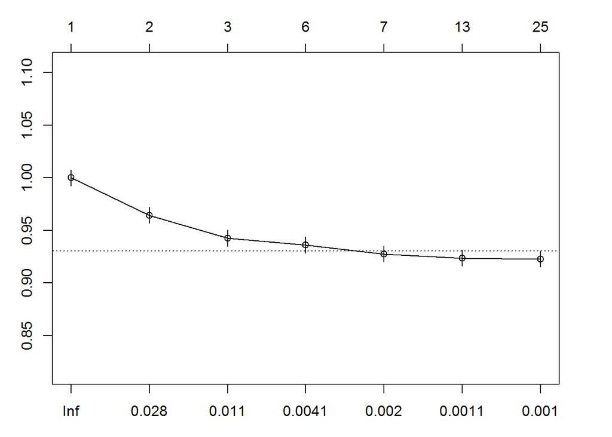

```r
#Validation of decision tree using the 'Complexity Parameter'

par(mar=c(3,3,3,3))
plotcp(cfit,lty = 3, col = 1)# Plotcp() provides a graphical representation to the cross validated error summary.
```

```r
printcp(cfit)# used to compute error rate on the sample used to fit the model.The value of cp should be least, so that the cross-validated error rate is minimum.
```

```
##
## Classification tree:
## rpart(formula = readmitted ~ time_in_hospital + num_lab_procedures +
##     num_procedures + num_medications + number_outpatient + number_emergency +
##     number_inpatient + race + age + admission_type_id + discharge_disposition_id +
##     admission_source_id + number_diagnoses + max_glu_serum +
##     A1Cresult + metformin + insulin, data = objTrain, method = "class",
##     minsplit = 20, minbucket = 5, cp = 0.001)
##
## Variables actually used in tree construction:
##  [1] admission_source_id      age
##  [3] discharge_disposition_id insulin
##  [5] max_glu_serum            metformin
##  [7] num_medications          num_procedures
##  [9] number_diagnoses         number_emergency
## [11] number_inpatient         number_outpatient
## [13] time_in_hospital
##
## Root node error: 9110/19612 = 0.46451
##
## n= 19612
##
##          CP nsplit rel error  xerror      xstd
## 1 0.0355653      0   1.00000 1.00000 0.0076668
## 2 0.0219539      1   0.96443 0.96443 0.0076445
## 3 0.0050494      2   0.94248 0.94259 0.0076266
## 4 0.0032931      5   0.92404 0.93611 0.0076207
## 5 0.0011855      6   0.92075 0.92766 0.0076125
## 6 0.0010977     12   0.91284 0.92360 0.0076084
## 7 0.0010000     24   0.89484 0.92283 0.0076076
```

```r
cfit$cptable[which.min(cfit$cptable[,"xerror"]),"CP"]# cp=0.001 #http://statmethods.net/advstats/cart.html
```

```
## [1] 0.001
```

```r
# Pruning and replotting the tree:
```

# Cross-validation of the tree

```r
library(tree)
cfit.tree <- tree(readmitted ~ time_in_hospital + num_lab_procedures + num_procedures + num_medications + number_outpatient + number_emergency + number_inpatient + race + age + admission_type_id + discharge_disposition_id + admission_source_id + number_diagnoses + max_glu_serum + A1Cresult + metformin + insulin, data = objTrain, method="class")

cv.cfit.tree <- cv.tree(cfit.tree, FUN = prune.misclass)
cv.cfit.tree
```

```
## $size
## [1] 2 1
##
## $dev
## [1] 8786 9110
##
## $k
## [1] -Inf  324
##
## $method
## [1] "misclass"
##
## attr(,"class")
## [1] "prune"         "tree.sequence"
```

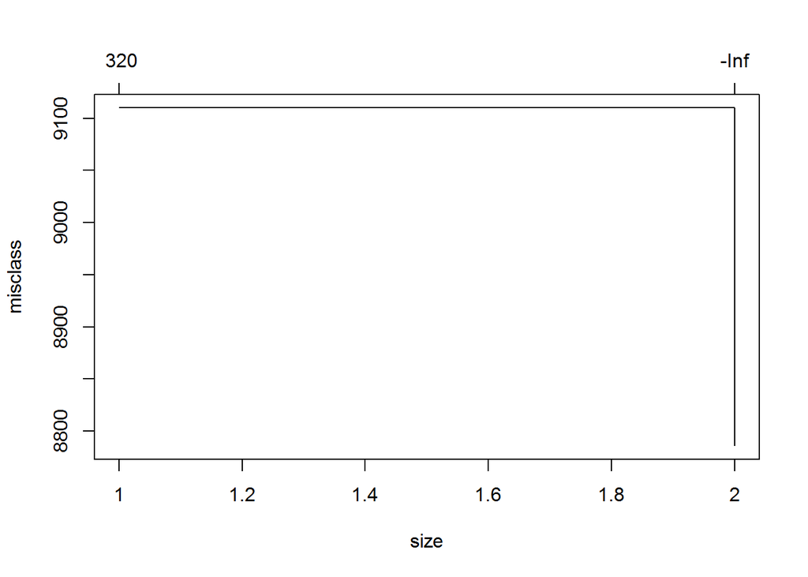

```r
plot.tree.sequence(cv.cfit.tree)
```

```r
prune.cfit.tree <- prune.misclass(cfit.tree, best = 2) # set size corresponding to the lowest value in the below plot.
summary(prune.cfit.tree)
```

```
##
## Classification tree:
## tree(formula = readmitted ~ time_in_hospital + num_lab_procedures +
##     num_procedures + num_medications + number_outpatient + number_emergency +
##     number_inpatient + race + age + admission_type_id + discharge_disposition_id +
##     admission_source_id + number_diagnoses + max_glu_serum +
##     A1Cresult + metformin + insulin, data = objTrain, method = "class")
## Variables actually used in tree construction:
## [1] "number_inpatient"
## Number of terminal nodes:  2
## Residual mean deviance:  1.851 = 36300 / 19610
## Misclassification error rate: 0.448 = 8786 / 19612
```

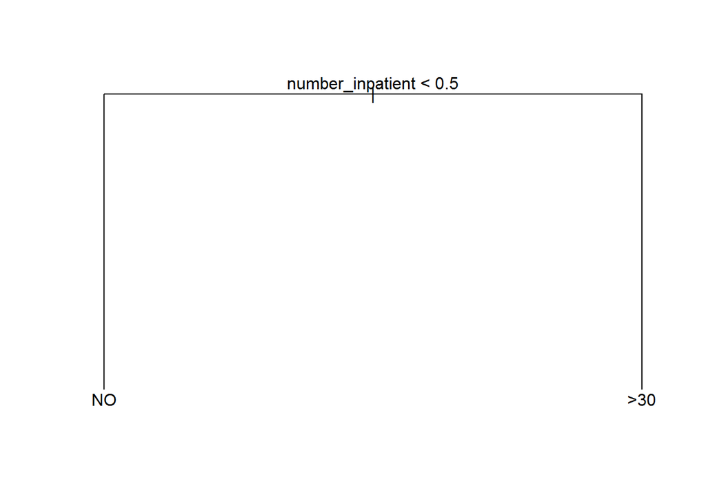

```r
plot(prune.cfit.tree)
text(prune.cfit.tree, pretty = 0)
```

#After pruning

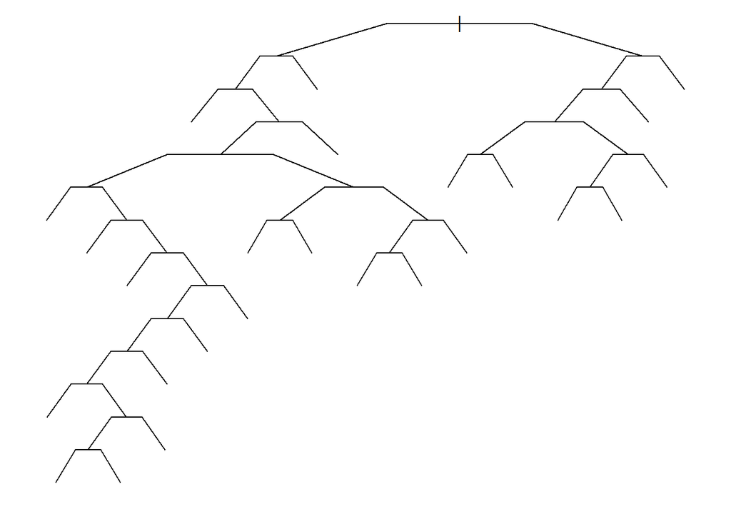

```r
cfit2 = prune(cfit, cp = 0.001)

par(mar=c(1,1,0.25,1))
plot(cfit2, branch = 0.4,uniform = TRUE, compress = TRUE)
```

```r
#text(cfit2)
```

# Using the pruned tree to predict and pulling up the mean error rate and confusion matrix

# Prediction on test set

```r
rpart.prune.predict <- predict(cfit2, newdata = objTest,type = "class")

cf.prune <-confusionMatrix(rpart.prune.predict,objTest$readmitted)
cf
```

```
## Confusion Matrix and Statistics
##
##           Reference
## Prediction  <30  >30   NO
##        <30   11    1    5
##        >30 1000 2882 1930
##        NO  1203 4013 8567
##
## Overall Statistics
##
##                Accuracy : 0.5843
##                  95% CI : (0.5774, 0.5912)
##     No Information Rate : 0.5355
##     P-Value [Acc > NIR] : < 2.2e-16
##
##                   Kappa : 0.1997
##  Mcnemar's Test P-Value : < 2.2e-16
##
## Statistics by Class:
##
##                      Class: <30 Class: >30 Class: NO
## Sensitivity           0.0049684     0.4179    0.8157
## Specificity           0.9996551     0.7696    0.4274
## Pos Pred Value        0.6470588     0.4959    0.6216
## Neg Pred Value        0.8875734     0.7091    0.6680
## Prevalence            0.1128901     0.3516    0.5355
## Detection Rate        0.0005609     0.1470    0.4368
## Detection Prevalence  0.0008668     0.2963    0.7028
## Balanced Accuracy     0.5023118     0.5938    0.6216
```

```r
#Mean error rate
mean.error.rate.rpart.prune <- 1- cf.prune$overall[1]
mean.error.rate.rpart.prune#Accuracy=42.72%
```

```
##  Accuracy
## 0.4272256
```

```r
cf.prune$table
```

```
##           Reference
## Prediction   <30   >30    NO
##        <30    30    28    21
##        >30  3847 11188  8104
##        NO   4975 16537 33711
```

# Decision Tree with two class response variable

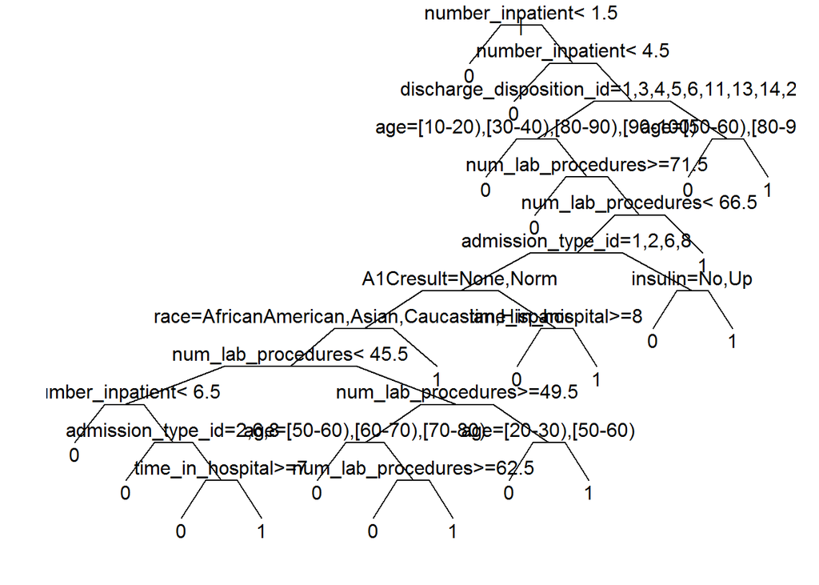

```r
cfit_bin <- rpart(readmittedbin ~ time_in_hospital + num_lab_procedures + num_procedures + num_medications + number_outpatient + number_emergency + number_inpatient + race + age + admission_type_id + discharge_disposition_id + admission_source_id + number_diagnoses + max_glu_serum + A1Cresult + metformin + insulin, data = objTrain, method="class", minsplit = 1, minbucket = 1, cp = 0.001)

par(mar=c(2,2,0.25,1))
plot(cfit_bin, branch = 0.4,uniform = TRUE, compress = TRUE)
text(cfit_bin, pretty = 0)
```

```r
#How to read plotcp - http://www.wekaleamstudios.co.uk/posts/classification-trees-using-the-rpart-function/#m3mLNpeke0I
rpart.predict_bin <- predict(cfit_bin, newdata = objTrain,type="prob")

View(objTrain)
head(rpart.predict_bin)
```

```
##            0          1
## 6  0.9061603 0.09383971
## 7  0.9061603 0.09383971
## 9  0.9061603 0.09383971
## 12 0.9061603 0.09383971
## 14 0.9061603 0.09383971
## 25 0.9061603 0.09383971
```

```r
View(rpart.predict_bin)

#https://www.rdocumentation.org/packages/ROSE/versions/0.0-3/topics/accuracy.meas
```

# ROC Curve

The closer the curve follows the left hand border and then the top left border of the ROC space, the more accurate the test. Displays the true positive rate (sensitivity) against the false positive rate (1-specificity).

```r
library(pROC)
library(ROSE)
```

```r
roc.curve(objTrain$readmittedbin, rpart.predict_bin[,2], plotit = T)
```

```
## Area under the curve (AUC): 0.585
```

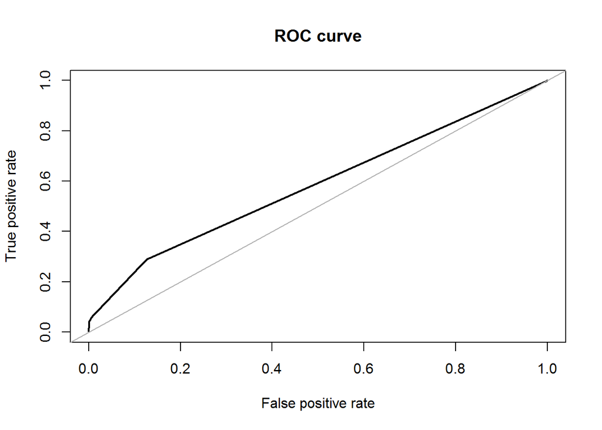

```
## Area under the curve (AUC): 0.585
```

```r
roc.curve(objTrain$readmittedbin, rpart.predict_bin[,2], plotit = T)
```

```r
## Area under the curve (AUC): 0.585 #https://en.wikipedia.org/wiki/Receiver_operating_characteristic#Area_under_the_curve
par =TRUE

#AUC = 0.58 is a terribly low score. Therefore, it is necessary to balanced data before applying any models . I have used the sampling techniques and try to improve this prediction accuracy.
```

# After pruning

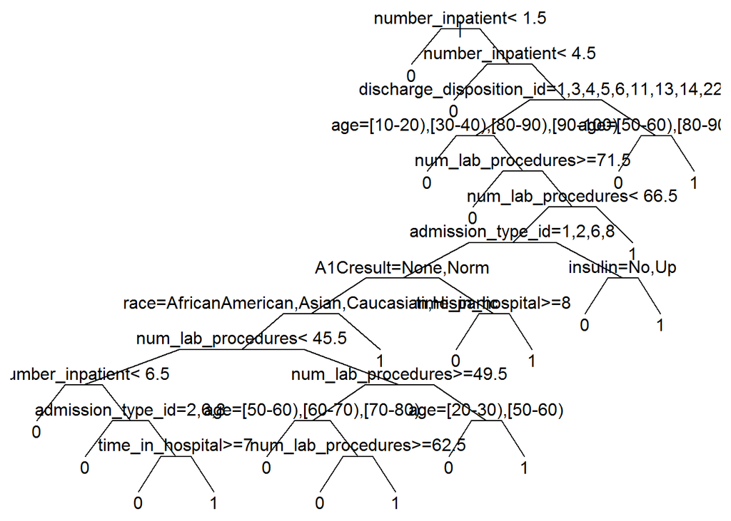

```r
cfit2_bin = prune(cfit_bin, cp = 0.0001)

par(mar=c(.5,.5,.5,.5))
plot(cfit2_bin, branch = 0.4,uniform = TRUE, compress = TRUE)
text(cfit2_bin, pretty=0)
```

#Prediction on training set

```r
rpart.prune.predict2_bin <- predict(cfit2_bin, newdata = objTrain,type = "class")

cf.prune_bin <-confusionMatrix(rpart.prune.predict2_bin,objTrain$readmittedbin)
cf.prune_bin
```

```
## Confusion Matrix and Statistics
##
##           Reference
## Prediction     0     1
##          0 17372  2119
##          1    26    95
##
##                Accuracy : 0.8906
##                  95% CI : (0.8862, 0.895)
##     No Information Rate : 0.8871
##     P-Value [Acc > NIR] : 0.0606
##
##                   Kappa : 0.0705
##  Mcnemar's Test P-Value : <2e-16
##
##             Sensitivity : 0.99851
##             Specificity : 0.04291
##          Pos Pred Value : 0.89128
##          Neg Pred Value : 0.78512
##              Prevalence : 0.88711
##          Detection Rate : 0.88578
##    Detection Prevalence : 0.99383
##       Balanced Accuracy : 0.52071
##
##        'Positive' Class : 0
##
```

```r
 #Accuracy   = 89.06%
 #Sensitivity= 99.85%
 #Specifcity = 4.29%


#Mean error rate
mean.error.rate.rpart.prune2 <- 1- cf.prune_bin$overall[1]
mean.error.rate.rpart.prune
```

```
##  Accuracy
## 0.4272256
```

```r
#Accuracy=42.72%
```

# over sampling

```r
table(objTrain$readmittedbin)
```

```
##
##     0     1
## 17398  2214
```

```r
data_balanced_over <- ovun.sample(readmittedbin ~ time_in_hospital + num_lab_procedures + num_procedures + num_medications + number_outpatient + number_emergency + number_inpatient + race + age + admission_type_id + discharge_disposition_id + admission_source_id + number_diagnoses + max_glu_serum + A1Cresult + metformin + insulin,  data = objTrain, method = "over", N = 34794)$data

table(data_balanced_over$readmittedbin) #Number of Observations with No Readmission and Readmission after 30 days= 17398 and Number of Observations with readmission within 30 days=17396
```

```
##
##     0     1
## 17398 17396
```

# under sampling

```r
data_balanced_under <- ovun.sample(readmittedbin ~ time_in_hospital + num_lab_procedures + num_procedures + num_medications + number_outpatient + number_emergency + number_inpatient + race + age + admission_type_id + discharge_disposition_id + admission_source_id + number_diagnoses + max_glu_serum + A1Cresult + metformin + insulin,  data = objTrain, method = "under", N = 4428, seed=1)$data

table(data_balanced_under$readmittedbin)
```

```
##
##    0    1
## 2214 2214
```

# Balanced sampling

Let us do both undersampling and oversampling on this imbalanced data. This can be achieved using method = “both”. In this case, the minority class is oversampled with replacement and majority class is undersampled without replacement.

```r
set.seed(123)
data_balanced_both <- ovun.sample(readmittedbin ~ time_in_hospital + num_lab_procedures + num_procedures + num_medications + number_outpatient + number_emergency + number_inpatient + race + age + admission_type_id + discharge_disposition_id + admission_source_id + number_diagnoses + max_glu_serum + A1Cresult + metformin + insulin, data = objTrain, method = "both", N = 19610, seed=1)$data

table(data_balanced_both$readmittedbin)
```

```
##
##    0    1
## 9847 9763
```

# ROSE SYTHETIC DATA BALANCING

ROSE helps us to generate data synthetically. This data is considered to provide better estimate of original data.

```r
set.seed(123)
data.rose <- ROSE(readmittedbin ~ time_in_hospital +num_lab_procedures + num_procedures + num_medications + number_outpatient + number_emergency + number_inpatient + race + age + admission_type_id + discharge_disposition_id + admission_source_id + number_diagnoses + max_glu_serum + A1Cresult + metformin + insulin, data = objTrain,seed=1)$data

table(data.rose$readmittedbin)
```

```
##
##    0    1
## 9848 9764
```

# building a decision tree models-Rose

```r
library(pROC)
library(gplots)
library(ggplot2)
cfit.rose <- rpart(readmittedbin ~ time_in_hospital + num_lab_procedures + num_procedures + num_medications + number_outpatient + number_emergency + number_inpatient + race + age + admission_type_id + discharge_disposition_id + admission_source_id + number_diagnoses + max_glu_serum + A1Cresult + metformin + insulin, data = data.rose)

#head(data.rose)

rpart.predict.rose <- predict(cfit.rose, newdata = data.rose)
par(2,2,2,2)
```

```r
par(new=TRUE)
```

```r
#roc.curve(data.rose$readmittedbin, rpart.predict.rose[,2], col = redblue(1000), add =TRUE) #0.690


#Prediction on rose set
rpart.prune.predict3_bin <- predict(cfit.rose, newdata = data.rose,type = "class")

cf.prune_bin <-confusionMatrix(rpart.prune.predict3_bin,objTrain$readmittedbin)
cf.prune_bin
```

```
## Confusion Matrix and Statistics
##
##           Reference
## Prediction     0     1
##          0 10588  1374
##          1  6810   840
##
##                Accuracy : 0.5827
##                  95% CI : (0.5758, 0.5896)
##     No Information Rate : 0.8871
##     P-Value [Acc > NIR] : 1
##
##                   Kappa : -0.0058
##  Mcnemar's Test P-Value : <2e-16
##
##             Sensitivity : 0.6086
##             Specificity : 0.3794
##          Pos Pred Value : 0.8851
##          Neg Pred Value : 0.1098
##              Prevalence : 0.8871
##          Detection Rate : 0.5399
##    Detection Prevalence : 0.6099
##       Balanced Accuracy : 0.4940
##
##        'Positive' Class : 0
##
```

```r
#Accuracy   = 58.27%
#Sensitivity= 60.86%
#Specificity= 37.94%


#Mean error rate
mean.error.rate.rpart.prune2 <- 1- cf.prune_bin$overall[1]
mean.error.rate.rpart.prune2 # Accuracy=41.72%
```

```
##  Accuracy
## 0.4172955
```

# Decision tree models-over sampling

```r
cfit.over <- rpart(readmittedbin ~ time_in_hospital + num_lab_procedures + num_procedures + num_medications + number_outpatient + number_emergency + number_inpatient + race + age + admission_type_id + discharge_disposition_id + admission_source_id + number_diagnoses + max_glu_serum + A1Cresult + metformin + insulin,  data = data_balanced_over)

rpart.predict.over <- predict(cfit.over, newdata = data_balanced_over)
```

# Decision tree model-undersampling

```r
library(ggplot2)
library(ROSE)
cfit.under <- rpart(readmittedbin ~ time_in_hospital + num_lab_procedures + num_procedures + num_medications + number_outpatient + number_emergency + number_inpatient + race + age + admission_type_id + discharge_disposition_id + admission_source_id + number_diagnoses + max_glu_serum + A1Cresult + metformin + insulin,   data = data_balanced_under)

rpart.predict.under <- predict(cfit.over, newdata = data_balanced_under)
par(new=TRUE)
#roc.curve(data_balanced_under$readmittedbin, rpart.predict.under[,2], add =TRUE, col = bluered(2))# AUC=0.634
```

# Decision tree model-both under and over sampling

```r
library(gplots)
library(ggplot2)

cfit.both <- rpart(readmittedbin ~ time_in_hospital + num_lab_procedures + num_procedures + num_medications + number_outpatient + number_emergency + number_inpatient + race + age + admission_type_id + discharge_disposition_id + admission_source_id + number_diagnoses + max_glu_serum + A1Cresult + metformin + insulin,  data = data_balanced_both)

rpart.predict.both <- predict(cfit.both, newdata = data_balanced_both)
#roc.curve(data_balanced_both$readmittedbin, rpart.predict.both[,2],add =TRUE, col = redblue(5)) # Auc=0.634
```